# Computer Vision & Convolution Neural Network - Project - 1

## •DOMAIN: Botanical research

#### CONTEXT: University X is currently undergoing some research involving understanding the characteristics of plant and plant seedlings at various stages of growth. They already have have invested on curating sample images. They require an automation which can create a classifier capable of determining a plant's species from a photo

```python
import tensorflow as tf
device_name = tf.test.gpu_device_name()
if device_name != '/device:GPU:0':
  raise SystemError('GPU device not found')
print('Found GPU at: {}'.format(device_name))

tf.__version__
```

```
Found GPU at: /device:GPU:0
```

```
'2.6.0'
```

```python
import numpy as np
import pandas as pd
import seaborn as sns
import scipy.stats as stats
import matplotlib.pyplot as plt
from tensorflow import keras
%matplotlib inline
from glob import glob
from tqdm import tqdm
import cv2

from sklearn.datasets import load_files
from sklearn.metrics import confusion_matrix, classification_report
from keras.utils import np_utils
from keras.preprocessing import image
from sklearn.model_selection import train_test_split
from tensorflow.keras.models import Sequential, model_from_json
from keras.layers import Conv2D, MaxPooling2D, GlobalAveragePooling2D, Dropout, Flatten, Dense ,Input
from tensorflow.keras import regularizers, optimizers
from keras.callbacks import ModelCheckpoint, ReduceLROnPlateau
from keras.preprocessing.image import ImageDataGenerator, array_to_img, img_to_array, load_img
from sklearn.metrics import r2_score
from tensorflow.keras.models import load_model
import io
import warnings
warnings.filterwarnings("ignore")
```

### Part 1 - Import the data. Analyse the dimensions of the data. Visualise the data

```python
from google.colab import drive
drive.mount('/content/drive')
```

```python
!ls '/content/drive/MyDrive'
```

```
'Colab Notebooks'  'Seedling - Prediction'   train
```

```python
def load_dataset(path):
    data=load_files(path)
    plant_files=np.array(data['filenames'])
    plant_targets=np_utils.to_categorical(np.array(data['target']),12)
    return plant_files,plant_targets

print('Loading Train Files')
train_files, train_targets = load_dataset('/content/drive/MyDrive/train')
print('Loading Complete!')
print('There are %d training plant images.' % len(train_files))
```

```
Loading Train Files
Loading Complete!
There are 4767 training plant images.
```

```python
plant_names= [item[29:-1] for item in sorted(glob("/content/drive/MyDrive/train/*"))]
print('There are %d total plant categories.' % len(plant_names))

plant_names
```

```
There are 12 total plant categories.
```

```
['Black-gras',
 'Charloc',
 'Cleaver',
 'Common Chickwee',
 'Common whea',
 'Fat He',
 'Loose Silky-ben',
 'Maiz',
 'Scentless Maywee',
 'Shepherds Purs',
 'Small-flowered Cranesbil',
 'Sugar bee']
```

```python
def path_to_tensor(img_path):
    # loads RGB image as PIL.Image.Image type
    img = image.load_img(img_path, target_size=(256, 256))
    # convert PIL.Image.Image type to 3D tensor with shape (256, 256, 3)
    x = image.img_to_array(img)
    # convert 3D tensor to 4D tensor with shape (1, 256, 256, 3) and return 4D tensor
    return np.expand_dims(x, axis=0)

def paths_to_tensor(img_paths):
    list_of_tensors = [path_to_tensor(img_path) for img_path in tqdm(img_paths)]
    return np.vstack(list_of_tensors)
```

```python
train_tensors = paths_to_tensor(train_files).astype('float32')/255
```

```python
train_tensors.shape
```

```
(4767, 256, 256, 3)
```

[figure not shown]

```python
fig, axs = plt.subplots(1, 4, figsize=(15,15));

axs[0].imshow(train_tensors[0]);
axs[1].imshow(train_tensors[15]);
axs[2].imshow(train_tensors[10]);
axs[3].imshow(train_tensors[89]);
```

```python
# do not change seed to reproduce my results
seed = 31
np.random.seed(seed)



# Split the train and the validation set
train_tensors, val_train, train_targets, val_targets = train_test_split(train_tensors,train_targets, test_size=0.15,random_state=seed)

print(train_tensors.shape)
print(val_train.shape)
print(train_targets.shape)
print(val_targets.shape)
```

```
(4051, 256, 256, 3)
(716, 256, 256, 3)
(4051, 12)
(716, 12)
```

### Part - 2 - Design, train tune and test the best AIML image classifier model

```python
model= Sequential()

model.add(Conv2D(filters = 16, kernel_size = (5,5),padding = 'Same', activation ='relu',input_shape=(256,256,3)))
model.add(MaxPooling2D(pool_size=2))
model.add(Dropout(0.1))

model.add(Conv2D(filters = 32, kernel_size = (5,5),padding = 'Same', activation ='relu'))
model.add(Conv2D(filters = 32, kernel_size = (5,5),padding = 'Same', activation ='relu'))
model.add(MaxPooling2D(pool_size=2))
model.add(Dropout(0.1))

model.add(Conv2D(filters = 64, kernel_size = (3,3),padding = 'Same', activation ='relu'))
model.add(Conv2D(filters = 64, kernel_size = (3,3),padding = 'Same', activation ='relu'))
model.add(MaxPooling2D(pool_size=2))
model.add(Dropout(0.1))


model.add(Conv2D(filters = 128, kernel_size = (3,3),padding = 'Same', activation ='relu'))
model.add(Conv2D(filters = 128, kernel_size = (3,3),padding = 'Same', activation ='relu'))
model.add(MaxPooling2D(pool_size=2))
model.add(Dropout(0.1))

model.add(GlobalAveragePooling2D())

model.add(Dense(256,activation='relu'))
model.add(Dropout(0.1))
model.add(Dense(12,activation='softmax'))

model.summary()
```

```
Model: "sequential"
_________________________________________________________________
Layer (type)                 Output Shape              Param #
=================================================================
conv2d (Conv2D)              (None, 256, 256, 16)      1216
_________________________________________________________________
max_pooling2d (MaxPooling2D) (None, 128, 128, 16)      0
_________________________________________________________________
dropout (Dropout)            (None, 128, 128, 16)      0
_________________________________________________________________
conv2d_1 (Conv2D)            (None, 128, 128, 32)      12832
_________________________________________________________________
conv2d_2 (Conv2D)            (None, 128, 128, 32)      25632
_________________________________________________________________
max_pooling2d_1 (MaxPooling2 (None, 64, 64, 32)        0
_________________________________________________________________
dropout_1 (Dropout)          (None, 64, 64, 32)        0
_________________________________________________________________
conv2d_3 (Conv2D)            (None, 64, 64, 64)        18496
_________________________________________________________________
conv2d_4 (Conv2D)            (None, 64, 64, 64)        36928
_________________________________________________________________
max_pooling2d_2 (MaxPooling2 (None, 32, 32, 64)        0
_________________________________________________________________
dropout_2 (Dropout)          (None, 32, 32, 64)        0
_________________________________________________________________
conv2d_5 (Conv2D)            (None, 32, 32, 128)       73856
_________________________________________________________________
conv2d_6 (Conv2D)            (None, 32, 32, 128)       147584
_________________________________________________________________
max_pooling2d_3 (MaxPooling2 (None, 16, 16, 128)       0
_________________________________________________________________
dropout_3 (Dropout)          (None, 16, 16, 128)       0
_________________________________________________________________
global_average_pooling2d (Gl (None, 128)               0
_________________________________________________________________
dense (Dense)                (None, 256)               33024
_________________________________________________________________
dropout_4 (Dropout)          (None, 256)               0
_________________________________________________________________
dense_1 (Dense)              (None, 12)                3084
=================================================================
Total params: 352,652
Trainable params: 352,652
Non-trainable params: 0
_________________________________________________________________
```

```python
from tensorflow.keras.optimizers import Adam

optimizer = Adam(lr=0.001, epsilon=1e-08, decay=0.0)
model.compile(optimizer = optimizer, loss = "categorical_crossentropy", metrics = ["accuracy"])
```

```python
checkpointer = ModelCheckpoint(filepath='saved_models/CNN_Model_1.hdf5', verbose=1, save_best_only=True)

history = model.fit(train_tensors, train_targets, epochs = 20, validation_data = (val_train,val_targets),callbacks=[checkpointer],batch_size = 64)
```

```
Epoch 00001: val_loss improved from inf to 2.41363, saving model to saved_models/CNN_Model_1.hdf5

Epoch 00002: val_loss improved from 2.41363 to 2.00039, saving model to saved_models/CNN_Model_1.hdf5

Epoch 00003: val_loss improved from 2.00039 to 1.81852, saving model to saved_models/CNN_Model_1.hdf5

Epoch 00004: val_loss improved from 1.81852 to 1.77297, saving model to saved_models/CNN_Model_1.hdf5

Epoch 00005: val_loss improved from 1.77297 to 1.67319, saving model to saved_models/CNN_Model_1.hdf5

Epoch 00006: val_loss improved from 1.67319 to 1.58522, saving model to saved_models/CNN_Model_1.hdf5

Epoch 00007: val_loss improved from 1.58522 to 1.45740, saving model to saved_models/CNN_Model_1.hdf5

Epoch 00008: val_loss improved from 1.45740 to 1.34433, saving model to saved_models/CNN_Model_1.hdf5

Epoch 00009: val_loss improved from 1.34433 to 1.33969, saving model to saved_models/CNN_Model_1.hdf5

Epoch 00010: val_loss did not improve from 1.33969

Epoch 00011: val_loss improved from 1.33969 to 1.18343, saving model to saved_models/CNN_Model_1.hdf5

Epoch 00012: val_loss improved from 1.18343 to 0.99740, saving model to saved_models/CNN_Model_1.hdf5

Epoch 00013: val_loss improved from 0.99740 to 0.94338, saving model to saved_models/CNN_Model_1.hdf5

Epoch 00014: val_loss improved from 0.94338 to 0.71495, saving model to saved_models/CNN_Model_1.hdf5

Epoch 00015: val_loss did not improve from 0.71495

Epoch 00016: val_loss improved from 0.71495 to 0.58567, saving model to saved_models/CNN_Model_1.hdf5

Epoch 00017: val_loss improved from 0.58567 to 0.52551, saving model to saved_models/CNN_Model_1.hdf5

Epoch 00018: val_loss improved from 0.52551 to 0.51714, saving model to saved_models/CNN_Model_1.hdf5

Epoch 00019: val_loss did not improve from 0.51714

Epoch 00020: val_loss did not improve from 0.51714
```

```python
learning_rate_reduction = ReduceLROnPlateau(monitor='val_acc', patience=3, verbose=1, factor=0.5, min_lr=0.0001)
```

```python
datagen = ImageDataGenerator(
        featurewise_center=False,  # set input mean to 0 over the dataset
        samplewise_center=False,  # set each sample mean to 0
        featurewise_std_normalization=False,  # divide inputs by std of the dataset
        samplewise_std_normalization=False,  # divide each input by its std
        zca_whitening=False,  # apply ZCA whitening
        rotation_range=10,  # randomly rotate images in the range (degrees, 0 to 180)
        zoom_range = 0.1, # Randomly zoom image
        width_shift_range=0.1,  # randomly shift images horizontally (fraction of total width)
        height_shift_range=0.1,  # randomly shift images vertically (fraction of total height)
        horizontal_flip=False,  # randomly flip images
        vertical_flip=False)  # randomly flip images


datagen.fit(train_tensors)
```

```python
batch = 32

checkpointer = ModelCheckpoint(filepath='saved_models/CNN_Model_2.hdf5',
                               verbose=1, save_best_only=True)

history = model.fit_generator(datagen.flow(train_tensors,train_targets,batch_size=batch),epochs = 30, validation_data = (val_train,val_targets),
                              verbose = 1, steps_per_epoch=train_tensors.shape[0] // batch
                              , callbacks=[learning_rate_reduction, checkpointer])
```

[output not shown]

[output cut: 35 more lines]

[output not shown]

```python
model.load_weights('saved_models/CNN_Model_2.hdf5')
accuracy=model.evaluate(x = val_train, y=val_targets, batch_size=32)
print("Loss of the model: {} , Accuracy of Model :{} ".format(accuracy[0], accuracy[1]))
```

```
Loss of the model: 0.24685585498809814 , Accuracy of Model :0.924580991268158
```

```
dict_keys(['loss', 'accuracy', 'val_loss', 'val_accuracy', 'lr'])
```

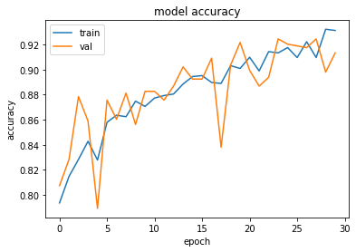

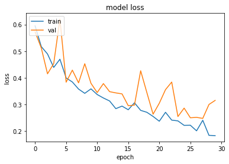

```python
# list all data in history
print(history.history.keys())
# summarize history for accuracy
plt.plot(history.history['accuracy'])
plt.plot(history.history['val_accuracy'])
plt.title('model accuracy')
plt.ylabel('accuracy')
plt.xlabel('epoch')
plt.legend(['train', 'val'], loc='upper left')
plt.show()
# summarize history for loss
plt.plot(history.history['loss'])
plt.plot(history.history['val_loss'])
plt.title('model loss')
plt.ylabel('loss')
plt.xlabel('epoch')
plt.legend(['train', 'val'], loc='upper left')
plt.show()
```